# Task 2 Statistical Learning 2020

Group 3

May 29th, 2020

```r
# libraries
library(keras)
library(rstatix)
library(tidyverse)
library(caret)
library(ggplot2)
library(gridExtra)
library(tfruns)
library(kableExtra)
library(caret)
library(plyr)


# set seed for reproductibility
set.seed(42)
tensorflow::tf$random$set_seed(42)

#load saved data
#load("data_q1to8.RData")
```

# Question 1&2

*Normalize the images. Split the dataset into 500 training /100 validation /100 test. Try to balance the two classes.*

We create a function `random_files` to automatically split the data in the required folder structure and in training, validation and test sets.

We then execute our function and define the training, validation and test folders.

```r
# execute function
random_files('rxtorax/normal','rxtorax', 1, 250, 50, 50, pattern = "png$|PNG$")
random_files('rxtorax/effusion','rxtorax', 2, 250, 50, 50, pattern = "png$|PNG$")
```

```r
# define training, validation and test folders
train_dir<-"rxtorax/train"
validation_dir<-"rxtorax/validation"
test_dir<-"rxtorax/test"
```

We then use `image_data_generator` to normalize our data and `flow_images_from_directory` to define batches, resize our images and keep a unique channel. We start with a batch size of 25.

```r
b_size <- 25

train_datagen <- image_data_generator(rescale = 1/255)
train_generator <- flow_images_from_directory(
  train_dir,
  train_datagen,
  color_mode = "grayscale",
  target_size = c(64, 64),
  batch_size = b_size,
  class_mode = "binary"
)

validation_datagen <- image_data_generator(rescale = 1/255)
validation_generator <- flow_images_from_directory(
  validation_dir,
  validation_datagen,
  color_mode = "grayscale",
  target_size = c(64, 64),
  batch_size = b_size,
  class_mode = "binary"
)

test_datagen <- image_data_generator(rescale = 1/255)
test_generator <- flow_images_from_directory(
  test_dir,
  test_datagen,
  color_mode = "grayscale",
  target_size = c(64, 64),
  batch_size = b_size,
  class_mode = "binary",
  classes = c("effusion","normal"),
  shuffle = FALSE
)
# Now we have the images in the required format: 64x64 with a unique channel
```

# Question 3

*Implement a Convolutional Neural Network (CNN).*

We then define a Convolutional Neural Network, with 2 convolution layers, each with its own pooling layer. Then we add a flatten layer and a dropout layer. At the bottom of the network we have two fully connected layers with 128 and 32 nodes respectively. Finally, the output layer has one unit and a sigmoid activation function. The total number of trainable parameters is 816 673.

```r
model <- keras_model_sequential() %>%
  # first convolutional hidden layer and max pooling
  layer_conv_2d(filters = 32, kernel_size = c(3,3),
                activation = "relu",input_shape = c(64, 64, 1)) %>%
  layer_max_pooling_2d(pool_size = c(2, 2)) %>%
  # second convolutional hidden layer and max pooling
  layer_conv_2d(filters = 32, kernel_size = c(3, 3),
                activation = "relu") %>%
  layer_max_pooling_2d(pool_size = c(2, 2)) %>%
  layer_flatten() %>%
  layer_dropout(rate=0.4) %>%
  # Outputs from dense layer are projected onto output layer
  layer_dense(units = 128, activation = "relu") %>%
  layer_dense(units = 32, activation = "relu") %>%
  layer_dense(units = 1, activation = "sigmoid")

summary(model)
```

```
## Model: "sequential"
## ________________________________________________________________________________
## Layer (type)                        Output Shape                    Param #
## ================================================================================
## conv2d (Conv2D)                     (None, 62, 62, 32)              320
## ________________________________________________________________________________
## max_pooling2d (MaxPooling2D)        (None, 31, 31, 32)              0
## ________________________________________________________________________________
## conv2d_1 (Conv2D)                   (None, 29, 29, 32)              9248
## ________________________________________________________________________________
## max_pooling2d_1 (MaxPooling2D)      (None, 14, 14, 32)              0
## ________________________________________________________________________________
## flatten (Flatten)                   (None, 6272)                    0
## ________________________________________________________________________________
## dropout (Dropout)                   (None, 6272)                    0
## ________________________________________________________________________________
## dense (Dense)                       (None, 128)                     802944
## ________________________________________________________________________________
## dense_1 (Dense)                     (None, 32)                      4128
## ________________________________________________________________________________
## dense_2 (Dense)                     (None, 1)                       33
## ================================================================================
## Total params: 816,673
## Trainable params: 816,673
## Non-trainable params: 0
## ________________________________________________________________________________
```

We compile and fit the model with a binary crossentropy loss function, compute the accuracy and use 13 epochs. We save our model in the attached file `cnn_model_batch25.h5`.

```r
# Compile the model
model %>% compile(
  loss = "binary_crossentropy",
  optimizer = optimizer_rmsprop(lr = 1e-4),
  metrics = c("acc")
)

# Fit the model
history <- model %>% fit_generator(
  train_generator,
  steps_per_epoch = 500/b_size,
  epochs = 13,
  validation_data = validation_generator,
  validation_steps = 100/b_size
)
model %>% save_model_hdf5("cnn_model_batch25.h5")
```

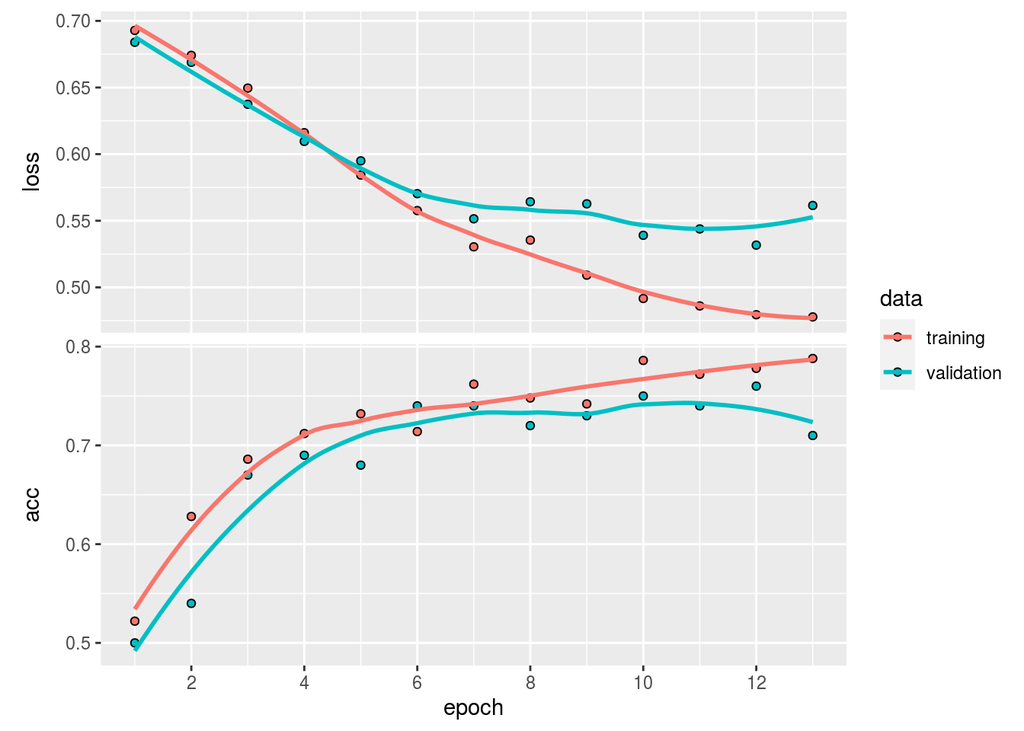

CNN accuracy on training and validation set

# Question 4

*Tune the hyperparameter batch_size checking the values 25, 35, 50.*

We use `tfruns` to tune the batch size hyperparameter.

```r
b_s <- c(25,35,50)
for (b in b_s) {
  training_run("cnn_flags.r", flags = c(batch_size = b))
}
```

```
##
## > set.seed(43)
##
## > tensorflow::tf$random$set_seed(43)
##
## > train_dir <- "rxtorax/train"
##
## > validation_dir <- "rxtorax/validation"
##
## > test_dir <- "rxtorax/test"
##
## > FLAGS <- flags(flag_numeric("batch_size", 25))
##
## > train_datagen <- image_data_generator(rescale = 1/255)
##
## > train_generator <- flow_images_from_directory(train_dir,
## +     train_datagen, color_mode = "grayscale", target_size = c(64,
## +         64), batch_s .... [TRUNCATED]
##
## > validation_datagen <- image_data_generator(rescale = 1/255)
##
## > validation_generator <- flow_images_from_directory(validation_dir,
## +     validation_datagen, color_mode = "grayscale", target_size = c(64,
## +       .... [TRUNCATED]
##
## > test_datagen <- image_data_generator(rescale = 1/255)
##
## > test_generator <- flow_images_from_directory(test_dir,
## +     test_datagen, color_mode = "grayscale", target_size = c(64,
## +         64), batch_size .... [TRUNCATED]
##
## > batch <- generator_next(train_generator)
##
## > str(batch)
## List of 2
##  $ : num [1:25, 1:64, 1:64, 1] 0 0.0588 0.0706 0.0235 0 ...
##  $ : num [1:25(1d)] 0 1 1 1 1 1 0 0 0 1 ...
##
## > model <- keras_model_sequential() %>% layer_conv_2d(filters = 32,
## +     kernel_size = c(3, 3), activation = "relu", input_shape = c(64,
```

[output cut: 173 more lines]

```
## dense_10 (Dense)                    (None, 32)                      4128
## ________________________________________________________________________________
## dense_11 (Dense)                    (None, 1)                       33
## ================================================================================
## Total params: 816,673
## Trainable params: 816,673
## Non-trainable params: 0
## ________________________________________________________________________________
##
## > model %>% compile(loss = "binary_crossentropy", optimizer = optimizer_rmsprop(lr = 1e-04),
## +     metrics = c("acc"))
##
## > history <- model %>% fit_generator(train_generator,
## +     steps_per_epoch = round(500/FLAGS$batch_size) + 1, epochs = 13,
## +     validation_data =  .... [TRUNCATED]
```

```r
tuning_res <- tfruns::ls_runs()
write_csv(tuning_res,"tfruns_res_batchsize.csv")
```

In Table , we present the output of the tuning. We find a batch size of 50 gives the best accuracy value on the validation set.

Batch size tuning results - loss and accuracy

| Batch size | Train. loss | Val. loss | Train. acc. | Val. acc |
| --- | --- | --- | --- | --- |
| 50 | 0.508 | 0.773 | 0.534 | 0.760 |
| 35 | 0.488 | 0.772 | 0.527 | 0.756 |
| 25 | 0.518 | 0.741 | 0.575 | 0.720 |

We set our batch size at 50, refit our model with that size and save our tuned model in the attached file `cnn_model_bestbatch.h5`.

```r
set.seed(43)
tensorflow::tf$random$set_seed(43)

b_size <- best_batch

# initialise the model
model_bestbatch <- keras_model_sequential() %>%
  # first convolutional hidden layer and max pooling
  layer_conv_2d(filters = 32, kernel_size = c(3,3),
                activation = "relu",input_shape = c(64, 64, 1)) %>%
  layer_max_pooling_2d(pool_size = c(2, 2)) %>%
  # second convolutional hidden layer and max pooling
  layer_conv_2d(filters = 32, kernel_size = c(3, 3),
                activation = "relu") %>%
  layer_max_pooling_2d(pool_size = c(2, 2)) %>%
  layer_flatten() %>%
  layer_dropout(rate=0.4) %>%
  # Outputs from dense layer are projected onto output layer
  layer_dense(units = 128, activation = "relu") %>%
  layer_dense(units = 32, activation = "relu") %>%
  layer_dense(units = 1, activation = "sigmoid")

# Compile the model
model_bestbatch %>% compile(
  loss = "binary_crossentropy",
  optimizer = optimizer_rmsprop(lr = 1e-4),
  metrics = c("acc")
)

# Fit the model
history_bestbatch <- model_bestbatch %>% fit_generator(
  train_generator,
  steps_per_epoch = 500/b_size,
  epochs = 13,
  validation_data = validation_generator,
  validation_steps = 100/b_size
)
model_bestbatch %>% save_model_hdf5("cnn_model_bestbatch.h5")
```

# Question 5

*Assess the performance of the CNN predicting the categories of test images and obtain the confusion matrix.*

We use `predict` to predict the class of our test images and gather the results in a dataframe.

```r
predict <- model_bestbatch %>% predict_generator(
  test_generator,
  steps = 100/b_size)

stat_df <- tibble(predict[1:100,], test_generator$filenames, test_generator$classes)
  # assign prediction probability for filenames
colnames(stat_df) <- c(
    "predict_proba",
    "filename",
    "class")
stat_df <- stat_df %>%
  mutate(predict_proba = as.double(predict_proba)) %>%
           mutate(predicted_class = ifelse(predict_proba > 0.5, 1, 0)) %>%
           mutate(predicted_class = as.integer(predicted_class)) %>%
  mutate(label_name = ifelse(predicted_class == 0, "effusion", "normal"))

test_accuracy <- mean(stat_df$class==stat_df$predicted_class)
```

We obtain an accuracy of 0.78 on the test set. The confusion matrix is:

```
## Confusion Matrix and Statistics
##
##           Reference
## Prediction  0  1
##          0 44 16
##          1  6 34
##
##                Accuracy : 0.78
##                  95% CI : (0.6861, 0.8567)
##     No Information Rate : 0.5
##     P-Value [Acc > NIR] : 7.953e-09
##
##                   Kappa : 0.56
##
##  Mcnemar's Test P-Value : 0.05501
##
##             Sensitivity : 0.8800
##             Specificity : 0.6800
##          Pos Pred Value : 0.7333
##          Neg Pred Value : 0.8500
##              Prevalence : 0.5000
##          Detection Rate : 0.4400
##    Detection Prevalence : 0.6000
##       Balanced Accuracy : 0.7800
##
##        'Positive' Class : 0
##
```

# Question 6 & 7

*Re-fit the CNN including data augmentation. Was the use of augmentation an improvement? Compare these two CNN models.*

We use `image_data_generator` to augment the training set of images and fit our model again with all the hyperparameters equal to our model without augmentation and the same seed. We save our augmented model in the attached file `cnn_model_bestbatch_augmented.h5`.

```r
datagen <- image_data_generator(
  rescale = 1/255,
  rotation_range = 40,
  width_shift_range = 0.2,
  height_shift_range = 0.2,
  shear_range = 0.2,
  zoom_range = 0.2,
  horizontal_flip = TRUE
)

set.seed(43)
tensorflow::tf$random$set_seed(43)

b_size <- best_batch

train_generator <- flow_images_from_directory(
  train_dir,
  datagen,
  color_mode = "grayscale",
  target_size = c(64, 64),
  batch_size = b_size,
  class_mode = "binary"
)

validation_datagen <- image_data_generator(rescale = 1/255)
validation_generator <- flow_images_from_directory(
  validation_dir,
  validation_datagen,
  color_mode = "grayscale",
  target_size = c(64, 64),
  batch_size = b_size,
  class_mode = "binary"
)

test_datagen <- image_data_generator(rescale = 1/255)
test_generator <- flow_images_from_directory(
  test_dir,
  test_datagen,
  color_mode = "grayscale",
  target_size = c(64, 64),
  batch_size = b_size,
  class_mode = "binary",
  classes = c("effusion","normal"),
  shuffle = FALSE
)

# initialise the model
model_bestbatch_aug <- keras_model_sequential() %>%
  # first convolutional hidden layer and max pooling
  layer_conv_2d(filters = 32, kernel_size = c(3,3),
                activation = "relu",input_shape = c(64, 64, 1)) %>%
  layer_max_pooling_2d(pool_size = c(2, 2)) %>%
  # second convolutional hidden layer and max pooling
  layer_conv_2d(filters = 32, kernel_size = c(3, 3),
                activation = "relu") %>%
  layer_max_pooling_2d(pool_size = c(2, 2)) %>%
  layer_flatten() %>%
  layer_dropout(rate=0.4) %>%
  # Outputs from dense layer are projected onto output layer
  layer_dense(units = 128, activation = "relu") %>%
  layer_dense(units = 32, activation = "relu") %>%
  layer_dense(units = 1, activation = "sigmoid")


# Compile the model
model_bestbatch_aug %>% compile(
  loss = "binary_crossentropy",
  optimizer = optimizer_rmsprop(lr = 1e-4),
  metrics = c("acc")
)

# Fit the model
history2 <- model_bestbatch_aug %>% fit_generator(
  train_generator,
  steps_per_epoch = 500/b_size,
  epochs = 13,
  validation_data = validation_generator,
  validation_steps = 100/b_size
)
model_bestbatch_aug %>% save_model_hdf5("cnn_model_bestbatch_augmented.h5")

# Prediction
predict_bestbatch_aug <- model_bestbatch_aug %>% predict_generator(
  test_generator,
  steps = 100/b_size)

stat_df_bestbatch_aug <- tibble(predict_bestbatch_aug, test_generator$filenames, test_generator$classes)
  # assign prediction probability for filenames
colnames(stat_df_bestbatch_aug) <- c(
    "predict_proba",
    "filename",
    "class")
stat_df_bestbatch_aug <- stat_df_bestbatch_aug %>%
  mutate(predict_proba = as.double(predict_proba)) %>%
           mutate(predicted_class = ifelse(predict_proba > 0.5, 1, 0)) %>%
           mutate(predicted_class = as.integer(predicted_class)) %>%
  mutate(label_name = ifelse(predicted_class == 0, "effusion", "normal"))

test_accuracy <- mean(stat_df_bestbatch_aug$class==stat_df_bestbatch_aug$predicted_class)
```

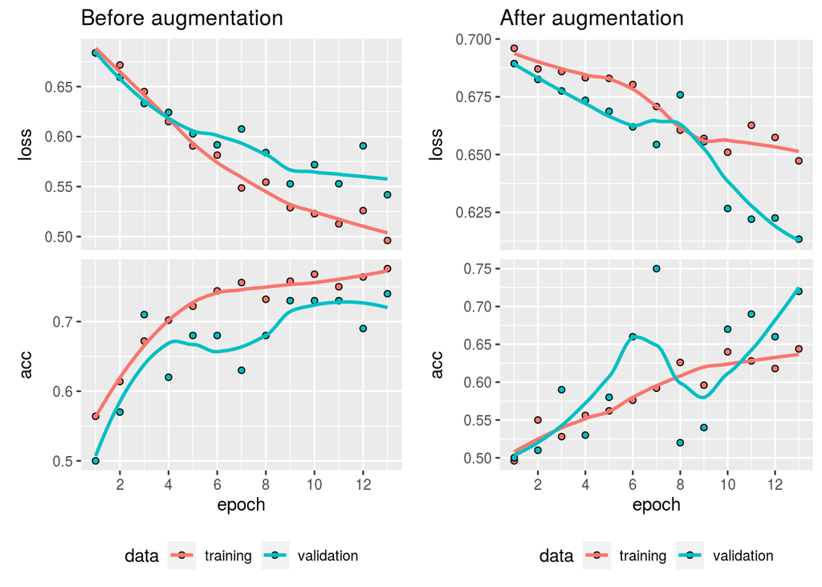

CNN loss and accuracy on training and validation set before and after augmentation

We also compare the two models on the test sample. For the CNN after augmentation we obtain an accuracy of 0.76 on the test set and the confusion matrix is:

```
## Confusion Matrix and Statistics
##
##           Reference
## Prediction  0  1
##          0 37 11
##          1 13 39
##
##                Accuracy : 0.76
##                  95% CI : (0.6643, 0.8398)
##     No Information Rate : 0.5
##     P-Value [Acc > NIR] : 9.05e-08
##
##                   Kappa : 0.52
##
##  Mcnemar's Test P-Value : 0.8383
##
##             Sensitivity : 0.7400
##             Specificity : 0.7800
##          Pos Pred Value : 0.7708
##          Neg Pred Value : 0.7500
##              Prevalence : 0.5000
##          Detection Rate : 0.3700
##    Detection Prevalence : 0.4800
##       Balanced Accuracy : 0.7600
##
##        'Positive' Class : 0
##
```

# Question 8

*Implement a convolutional autoencoder (CAE) network.*

We use `image_data_generator`to normalize our data and `flow_images_from_directory` to split our images in batches of size 50 with mode `input`.

We define a convolutionnal autoencoder with 3 convolutionnal layers in the encoder and 4 convolutionnal layers in the decoder. The number of filters is a decresing function of the layer order in the encoder and we start from 64 filters. The pooling size is set at 2 in the first two layers and then 4 in the third one. The decoder structure is symetric to the encoder one, with an additional layer to obtain an image of the same dimension as the input. The total number of trainable parameters is 89,729.

```r
#### Convolutional Encoder
filters_start <- 64
p_size <- 4

model_enc <- keras_model_sequential()
model_enc %>%
  layer_conv_2d(filters = filters_start, kernel_size = c(2,2), padding ="same",
                activation = "relu",input_shape = c(64, 64, 1)) %>%
  layer_max_pooling_2d(pool_size = c(2,2),padding ="same") %>%

  layer_conv_2d(filters = filters_start, kernel_size = c(2,2), padding ="same",
                activation = "relu") %>%
  layer_max_pooling_2d(pool_size = c(2,2),padding ="same") %>%

  layer_conv_2d(filters = filters_start/2, kernel_size = c(2,2), padding ="same",
                activation = "relu") %>%
  layer_max_pooling_2d(pool_size = c(p_size,p_size), padding ="same")
summary(model_enc)
```

```
## Model: "sequential_6"
## ________________________________________________________________________________
## Layer (type)                        Output Shape                    Param #
## ================================================================================
## conv2d_12 (Conv2D)                  (None, 64, 64, 64)              320
## ________________________________________________________________________________
## max_pooling2d_12 (MaxPooling2D)     (None, 32, 32, 64)              0
## ________________________________________________________________________________
## conv2d_13 (Conv2D)                  (None, 32, 32, 64)              16448
## ________________________________________________________________________________
## max_pooling2d_13 (MaxPooling2D)     (None, 16, 16, 64)              0
## ________________________________________________________________________________
## conv2d_14 (Conv2D)                  (None, 16, 16, 32)              8224
## ________________________________________________________________________________
## max_pooling2d_14 (MaxPooling2D)     (None, 4, 4, 32)                0
## ================================================================================
## Total params: 24,992
## Trainable params: 24,992
## Non-trainable params: 0
## ________________________________________________________________________________
```

```r
#### Convolutional Decoder

model_dec <- keras_model_sequential()
model_dec %>%
  layer_conv_2d(filters = filters_start/2, kernel_size = c(3,3),
                activation = "relu", padding = "same",
                input_shape = c(64/(2*2*p_size), 64/(2*2*p_size), filters_start/2))  %>%
  layer_upsampling_2d(size = c(2,2))  %>%

layer_conv_2d(filters = filters_start, kernel_size = c(3,3),
                activation = "relu", padding = "same")  %>%
  layer_upsampling_2d(size = c(2,2))  %>%

  layer_conv_2d(filters = filters_start, kernel_size = c(3,3),
                activation = "relu", padding = "same")  %>%
  layer_upsampling_2d(size = c(p_size,p_size))  %>%
  layer_conv_2d(filters = 1, kernel_size = c(1,1),
                activation = "relu")
summary(model_dec)
```

```
## Model: "sequential_7"
## ________________________________________________________________________________
## Layer (type)                        Output Shape                    Param #
## ================================================================================
## conv2d_15 (Conv2D)                  (None, 4, 4, 32)                9248
## ________________________________________________________________________________
## up_sampling2d (UpSampling2D)        (None, 8, 8, 32)                0
## ________________________________________________________________________________
## conv2d_16 (Conv2D)                  (None, 8, 8, 64)                18496
## ________________________________________________________________________________
## up_sampling2d_1 (UpSampling2D)      (None, 16, 16, 64)              0
## ________________________________________________________________________________
## conv2d_17 (Conv2D)                  (None, 16, 16, 64)              36928
## ________________________________________________________________________________
## up_sampling2d_2 (UpSampling2D)      (None, 64, 64, 64)              0
## ________________________________________________________________________________
## conv2d_18 (Conv2D)                  (None, 64, 64, 1)               65
## ================================================================================
## Total params: 64,737
## Trainable params: 64,737
## Non-trainable params: 0
## ________________________________________________________________________________
```

```r
#### Autoencoder
model_auto<-keras_model_sequential()
model_auto %>%model_enc%>%model_dec
```

```
## Model
## Model: "sequential_8"
## ________________________________________________________________________________
## Layer (type)                        Output Shape                    Param #
## ================================================================================
## sequential_6 (Sequential)           (None, 4, 4, 32)                24992
## ________________________________________________________________________________
## sequential_7 (Sequential)           (None, 64, 64, 1)               64737
## ================================================================================
## Total params: 89,729
## Trainable params: 89,729
## Non-trainable params: 0
## ________________________________________________________________________________
```

We use the mean squared error as loss function and 5 epochs.

```r
# set seed for reproductibility
set.seed(42)
tensorflow::tf$random$set_seed(42)

model_auto %>% compile(
  loss = "mean_squared_error",
  #optimizer = optimizer_rmsprop(),
  optimizer = "adam",
  metrics = c("mean_squared_error")
)

# Fit the model
history_auto <- model_auto %>% fit_generator(
  train_generator,
  steps_per_epoch = 500/b_size,
  epochs = 5,
  validation_data = validation_generator,
  validation_steps = 100/b_size
)
model_auto %>% save_model_hdf5("auto_model.h5")
save.image("data_q1to8.RData")
```

We see that after 5 epochs, the training and validation metrics are similar and stagnate. More epochs would lead to overfitting.

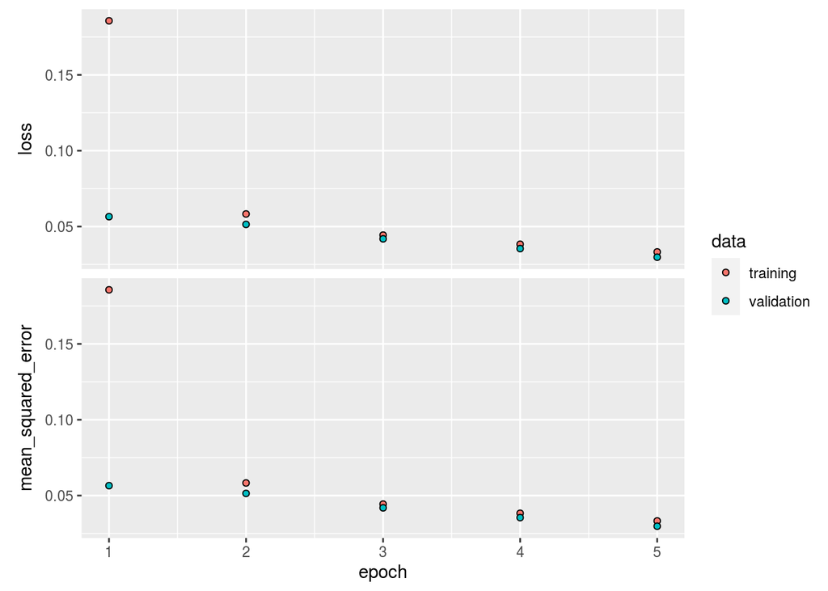

Autoencoder MSE on training and validation set

# Question 9

*Tune the more compact layer (z layer) with three configurations(width x heigth x filters) what you can free choose. To evaluate the z layer performance use this flattened layer as input in a random forest(or boosting) algorithm to classify the images.*

We use `tfruns` to run our convolutionnal autoencoder with different configurations of the encoder to obtain three different dimensions of the compact layer Z: (4,4,32), (4,4,64) and (8,8,64).

```r
training_run("cae_flags.R", flags = c(filters_nb_start = 64,
                                      pooling_size = 4))
```

```
##
## > FLAGS <- flags(flag_numeric("filters_nb_start", 32),
## +     flag_numeric("pooling_size", 2))
##
## > train_datagen <- image_data_generator(rescale = 1/255)
##
## > train_generator <- flow_images_from_directory(train_dir,
## +     train_datagen, color_mode = "grayscale", target_size = c(64,
## +         64), batch_s .... [TRUNCATED]
##
## > validation_datagen <- image_data_generator(rescale = 1/255)
##
## > validation_generator <- flow_images_from_directory(validation_dir,
## +     validation_datagen, color_mode = "grayscale", target_size = c(64,
## +       .... [TRUNCATED]
##
## > model_enc <- keras_model_sequential()
##
## > model_enc %>% layer_conv_2d(filters = FLAGS$filters_nb_start,
## +     kernel_size = c(2, 2), padding = "same", activation = "relu",
## +     input_shap .... [TRUNCATED]
##
## > model_dec <- keras_model_sequential()
##
## > model_dec %>% layer_conv_2d(filters = FLAGS$filters_nb_start/2,
## +     kernel_size = c(3, 3), activation = "relu", padding = "same",
## +     input_sh .... [TRUNCATED]
##
## > summary(model_dec)
## Model: "sequential_10"
## ________________________________________________________________________________
## Layer (type)                        Output Shape                    Param #
## ================================================================================
## conv2d_22 (Conv2D)                  (None, 4, 4, 32)                9248
## ________________________________________________________________________________
## up_sampling2d_3 (UpSampling2D)      (None, 8, 8, 32)                0
## ________________________________________________________________________________
## conv2d_23 (Conv2D)                  (None, 8, 8, 64)                18496
## ________________________________________________________________________________
## up_sampling2d_4 (UpSampling2D)      (None, 16, 16, 64)              0
```

[output cut: 67 more lines]

```
## [1] 100   4   4  32
##
## > dim(predict_enc_train) <- c(nrow(predict_enc_train),
## +     prod(dim(predict_enc_train)[-1]))
##
## > dim(predict_enc_test) <- c(nrow(predict_enc_test),
## +     prod(dim(predict_enc_test)[-1]))
##
## > y_radio_train <- train_generator$classes
##
## > y_radio_test <- test_generator$classes
##
## > save(predict_enc_train, y_radio_train, predict_enc_test,
## +     y_radio_train, file = paste0("Conv_Encod_Flat_filter", FLAGS$filters_nb_start,
## +    .... [TRUNCATED]
```

```r
training_run("cae_flags.R", flags = c(filters_nb_start = 128,
                                      pooling_size = 4))
```

```
##
## > FLAGS <- flags(flag_numeric("filters_nb_start", 32),
## +     flag_numeric("pooling_size", 2))
##
## > train_datagen <- image_data_generator(rescale = 1/255)
##
## > train_generator <- flow_images_from_directory(train_dir,
## +     train_datagen, color_mode = "grayscale", target_size = c(64,
## +         64), batch_s .... [TRUNCATED]
##
## > validation_datagen <- image_data_generator(rescale = 1/255)
##
## > validation_generator <- flow_images_from_directory(validation_dir,
## +     validation_datagen, color_mode = "grayscale", target_size = c(64,
## +       .... [TRUNCATED]
##
## > model_enc <- keras_model_sequential()
##
## > model_enc %>% layer_conv_2d(filters = FLAGS$filters_nb_start,
## +     kernel_size = c(2, 2), padding = "same", activation = "relu",
## +     input_shap .... [TRUNCATED]
##
## > model_dec <- keras_model_sequential()
##
## > model_dec %>% layer_conv_2d(filters = FLAGS$filters_nb_start/2,
## +     kernel_size = c(3, 3), activation = "relu", padding = "same",
## +     input_sh .... [TRUNCATED]
##
## > summary(model_dec)
## Model: "sequential_13"
## ________________________________________________________________________________
## Layer (type)                        Output Shape                    Param #
## ================================================================================
## conv2d_29 (Conv2D)                  (None, 4, 4, 64)                36928
## ________________________________________________________________________________
## up_sampling2d_6 (UpSampling2D)      (None, 8, 8, 64)                0
## ________________________________________________________________________________
## conv2d_30 (Conv2D)                  (None, 8, 8, 128)               73856
## ________________________________________________________________________________
## up_sampling2d_7 (UpSampling2D)      (None, 16, 16, 128)             0
```

[output cut: 67 more lines]

```
## [1] 100   4   4  64
##
## > dim(predict_enc_train) <- c(nrow(predict_enc_train),
## +     prod(dim(predict_enc_train)[-1]))
##
## > dim(predict_enc_test) <- c(nrow(predict_enc_test),
## +     prod(dim(predict_enc_test)[-1]))
##
## > y_radio_train <- train_generator$classes
##
## > y_radio_test <- test_generator$classes
##
## > save(predict_enc_train, y_radio_train, predict_enc_test,
## +     y_radio_train, file = paste0("Conv_Encod_Flat_filter", FLAGS$filters_nb_start,
## +    .... [TRUNCATED]
```

```r
training_run("cae_flags.R", flags = c(filters_nb_start = 128,
                                      pooling_size = 2))
```

```
##
## > FLAGS <- flags(flag_numeric("filters_nb_start", 32),
## +     flag_numeric("pooling_size", 2))
##
## > train_datagen <- image_data_generator(rescale = 1/255)
##
## > train_generator <- flow_images_from_directory(train_dir,
## +     train_datagen, color_mode = "grayscale", target_size = c(64,
## +         64), batch_s .... [TRUNCATED]
##
## > validation_datagen <- image_data_generator(rescale = 1/255)
##
## > validation_generator <- flow_images_from_directory(validation_dir,
## +     validation_datagen, color_mode = "grayscale", target_size = c(64,
## +       .... [TRUNCATED]
##
## > model_enc <- keras_model_sequential()
##
## > model_enc %>% layer_conv_2d(filters = FLAGS$filters_nb_start,
## +     kernel_size = c(2, 2), padding = "same", activation = "relu",
## +     input_shap .... [TRUNCATED]
##
## > model_dec <- keras_model_sequential()
##
## > model_dec %>% layer_conv_2d(filters = FLAGS$filters_nb_start/2,
## +     kernel_size = c(3, 3), activation = "relu", padding = "same",
## +     input_sh .... [TRUNCATED]
##
## > summary(model_dec)
## Model: "sequential_16"
## ________________________________________________________________________________
## Layer (type)                        Output Shape                    Param #
## ================================================================================
## conv2d_36 (Conv2D)                  (None, 8, 8, 64)                36928
## ________________________________________________________________________________
## up_sampling2d_9 (UpSampling2D)      (None, 16, 16, 64)              0
## ________________________________________________________________________________
## conv2d_37 (Conv2D)                  (None, 16, 16, 128)             73856
## ________________________________________________________________________________
## up_sampling2d_10 (UpSampling2D)     (None, 32, 32, 128)             0
```

[output cut: 67 more lines]

```
## [1] 100   8   8  64
##
## > dim(predict_enc_train) <- c(nrow(predict_enc_train),
## +     prod(dim(predict_enc_train)[-1]))
##
## > dim(predict_enc_test) <- c(nrow(predict_enc_test),
## +     prod(dim(predict_enc_test)[-1]))
##
## > y_radio_train <- train_generator$classes
##
## > y_radio_test <- test_generator$classes
##
## > save(predict_enc_train, y_radio_train, predict_enc_test,
## +     y_radio_train, file = paste0("Conv_Encod_Flat_filter", FLAGS$filters_nb_start,
## +    .... [TRUNCATED]
```

```r
tuning_res_dim <- tfruns::ls_runs() %>% filter(script == "cae_flags.R")
write_csv(tuning_res_dim,"tfruns_res_dim.csv")
```

On the training and validation set, the compact layer Z of dimension (8,8,64) gives the lowest MSE as shown in Table .

Z dimension tuning results - loss and MSE

| Dimension Z | Filter param | Pooling size | Train. loss | Val. loss | Train. MSE. | Val. MSE |
| --- | --- | --- | --- | --- | --- | --- |
| (8,8,64) | 128 | 2 | 0.012 | 0.012 | 0.011 | 0.011 |
| (4,4,64) | 128 | 4 | 0.028 | 0.028 | 0.024 | 0.024 |
| (4,4,32) | 64 | 4 | 0.031 | 0.031 | 0.028 | 0.028 |

In the runs, we extracted and flattened the compact layer Z for each dimension for the training and the test sets and saved it in Rdata files. We fit an adaboost model with stumps on the training Z for each combination. For computation time and power, we ran the code in a Google Colab virtual machine with the attached notebook `Adaboost on encoder output.ipynb`.

```r
combina <-c("filter128_pool2","filter128_pool4","filter64_pool4")
for (com in combina){
  load(paste0("Conv_Encod_Flat_",com,".RData"))
  training <- data.frame(y=as.factor(y_radio_train),predict_enc_train)
  nzv <- nearZeroVar(training)
  training <- training[, -nzv]
  #test <- data.frame(y=as.factor(y_radio_test),predict_enc_test)
  training$y <- revalue(training$y, c("0"="effusion", "1"="normal"))
  #test$y <- revalue(test$y, c("0"="effusion", "1"="normal"))

  control <- trainControl(
    method = "repeatedcv",
    number = 5,
    repeats = 3,
    classProbs = TRUE
    allowParallel = TRUE,
    summaryFunction = twoClassSummary
  )

  grid <- expand.grid(
    .interaction.depth = 1,
    .n.trees = c(500, 1500, 3000),
    .shrinkage = .01,
    .n.minobsinnode = 10
  )

  metric <- "Accuracy"

  stump_adaboost <- train(y ~ .,
    data = training,
    method = "gbm",
    bag.fraction = 0.5,
    distribution = "adaboost",
    trControl = control,
    tuneGrid = grid,
    verbose = FALSE,
    metric = metric
  )

  save(stump_adaboost,file=paste0("stump_adaboost",com,".Rdata"))
}
```

We compare the accuracy obtained with the different dimensions in the training set in Fig. where we plot the distributions of the ROC, Specificity and Sensitivity accross resamples. We see that in all the cases the ROC is poor, however a slightly larger ROC is achieved with the dimension (4,4,64). The sensitivity and specificity are comparable in the 3 cases.

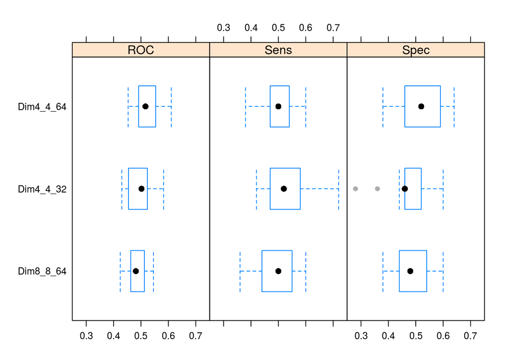

Adaboost model accuracy with different dimensions of compact layer Z

On the test set with dimension (4,4,32) we obtain the following confusion matrix and a ROC of 0.622.

```
## Confusion Matrix and Statistics
##
##           Reference
## Prediction effusion normal
##   effusion        0      0
##   normal         50     50
##
##                Accuracy : 0.5
##                  95% CI : (0.3983, 0.6017)
##     No Information Rate : 0.5
##     P-Value [Acc > NIR] : 0.5398
##
##                   Kappa : 0
##
##  Mcnemar's Test P-Value : 4.219e-12
##
##             Sensitivity : 0.0
##             Specificity : 1.0
##          Pos Pred Value : NaN
##          Neg Pred Value : 0.5
##              Prevalence : 0.5
##          Detection Rate : 0.0
##    Detection Prevalence : 0.0
##       Balanced Accuracy : 0.5
##
##        'Positive' Class : effusion
##
```

On the test set with dimension (4,4,64) we obtain the following confusion matrix and a ROC of 0.392.

```
## Confusion Matrix and Statistics
##
##           Reference
## Prediction effusion normal
##   effusion        3      3
##   normal         47     47
##
##                Accuracy : 0.5
##                  95% CI : (0.3983, 0.6017)
##     No Information Rate : 0.5
##     P-Value [Acc > NIR] : 0.5398
##
##                   Kappa : 0
##
##  Mcnemar's Test P-Value : 1.193e-09
##
##             Sensitivity : 0.06
##             Specificity : 0.94
##          Pos Pred Value : 0.50
##          Neg Pred Value : 0.50
##              Prevalence : 0.50
##          Detection Rate : 0.03
##    Detection Prevalence : 0.06
##       Balanced Accuracy : 0.50
##
##        'Positive' Class : effusion
##
```

On the test set with dimension (8,8,64) we obtain the following confusion matrix and a ROC of 0.536.

```
## Confusion Matrix and Statistics
##
##           Reference
## Prediction effusion normal
##   effusion        9      4
##   normal         41     46
##
##                Accuracy : 0.55
##                  95% CI : (0.4473, 0.6497)
##     No Information Rate : 0.5
##     P-Value [Acc > NIR] : 0.1841
##
##                   Kappa : 0.1
##
##  Mcnemar's Test P-Value : 8.025e-08
##
##             Sensitivity : 0.1800
##             Specificity : 0.9200
##          Pos Pred Value : 0.6923
##          Neg Pred Value : 0.5287
##              Prevalence : 0.5000
##          Detection Rate : 0.0900
##    Detection Prevalence : 0.1300
##       Balanced Accuracy : 0.5500
##
##        'Positive' Class : effusion
##
```

On the test set, models with dimensions (4,4,64) and (8,8,64) have very similar accuracy, however the ROC is larger for (8,8,64). We choose (8,8,64) as our best dimension.

# Question 10

*Once it was selected the best performing z layer configuration, to detect in which variables (nodes) there are significant differences between the two classes of images, a statistical test will be performed to determine those that are significant.*

We extract again the compact layer for the training set with dimension (8,8,64). For each variable, we run a t-test comparing the average value between the samples from the two classes and adjust for false discovery ratio with the Benjamini-Hochberg method.

In Table , we list the top 10 variables with the smallest p-values. In total we have 79 variables with significant difference in mean with a p-value cut off of 5% before adjustment. However, none of the variable has a significant difference in mean after adjustment for multi-testing.

T-test on compact layer variables means between classes

| variables | statistic | p | p.adj |
| --- | --- | --- | --- |
| X3798 | -2.92 | 0.004 | 0.999 |
| X2350 | -2.91 | 0.004 | 0.999 |
| X2355 | -2.82 | 0.005 | 0.999 |
| X2726 | -2.77 | 0.006 | 0.999 |
| X3412 | -2.76 | 0.006 | 0.999 |
| X2582 | -2.73 | 0.007 | 0.999 |
| X2070 | -2.66 | 0.008 | 0.999 |
| X4052 | -2.64 | 0.009 | 0.999 |
| X1029 | -2.57 | 0.010 | 0.999 |
| X1428 | -2.56 | 0.011 | 0.999 |

# Question 11

*Visualize the results of the previous item using Volcano plot.*

```r
stat.test <- stat.test %>% ungroup() %>% arrange(variables)

lfc<- training.long %>%
  dplyr::group_by(variables,y) %>%
  dplyr::summarise(log_mean = log2(mean(value)))

lfc <- pivot_wider(lfc, id_cols=variables, names_from = y, values_from = log_mean) %>%
  mutate(lfc=effusion-normal) %>%
  arrange(variables)

stat.test$lfc <- lfc$lfc
stat.test$log10pval <- -log10(stat.test$p)
```

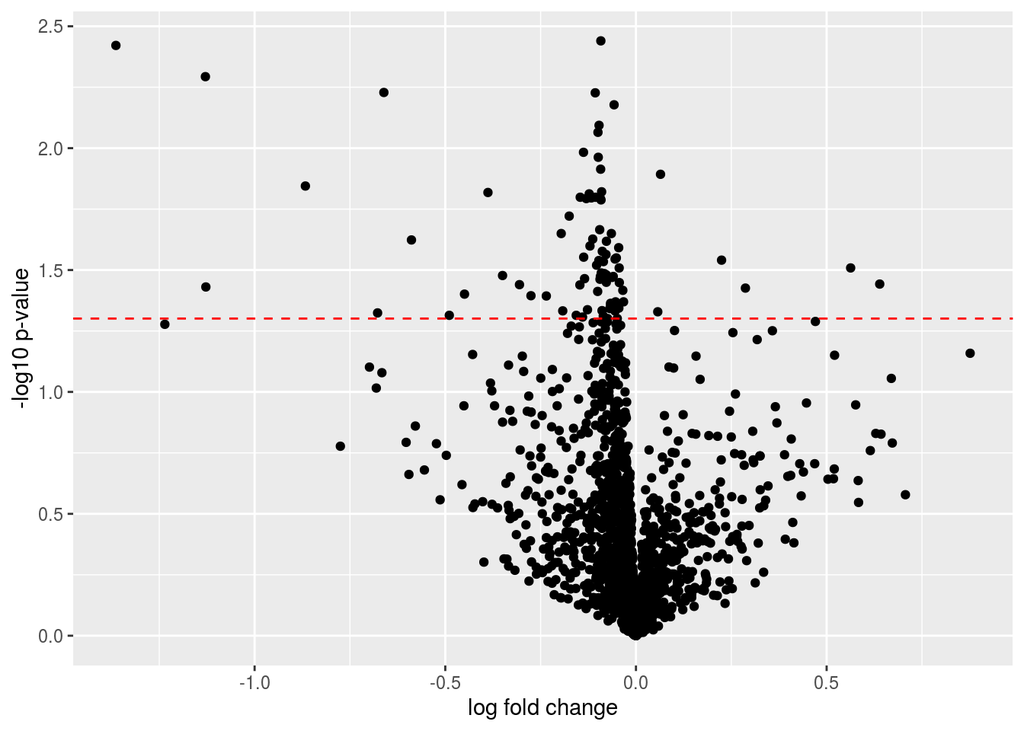

Volcano plot of differences in means of Z varibales